# Call Type Hotspots Analysis

Zain Ahmed, Raameen Ahmed, Mustafa Nasir

2025-08-09

# 911 Call Type Analysis

**Inquiry:** What are the spatial and categorical distributions of 911 call types across Detroit, and how do these patterns inform public safety resource allocation?

**Null Hypothesis:** There is no statistically significant relationship between call type frequency and geographic location.

**Hypothesis 1:** Certain call types cluster in specific geographic areas, indicating localized public safety needs.

**What this means:** Identifying call type hotspots enables targeted resource allocation, specialized response protocols, and preventive interventions at the neighborhood level.

**Disclaimer:** Call patterns are influenced by complex socioeconomic factors including population density, time of day, seasonal variations, and community resources as noted in urban safety literature.

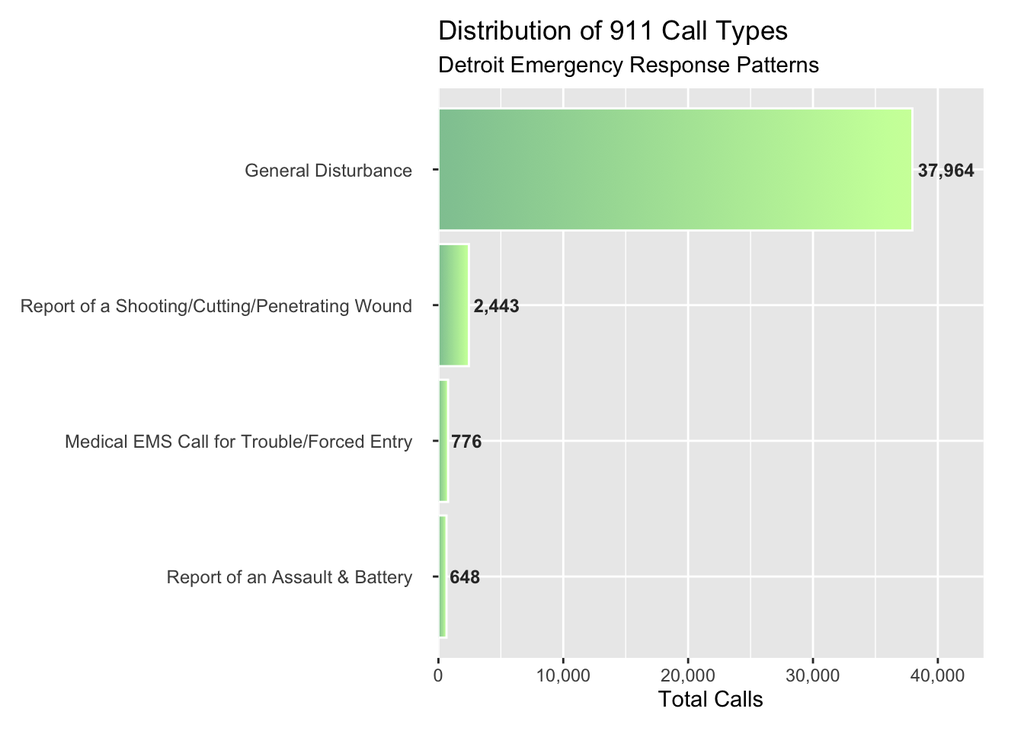

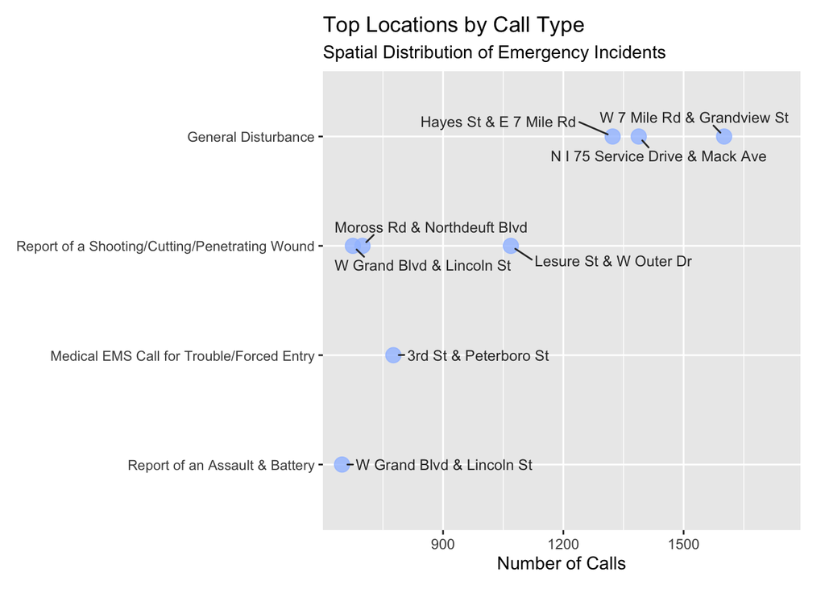

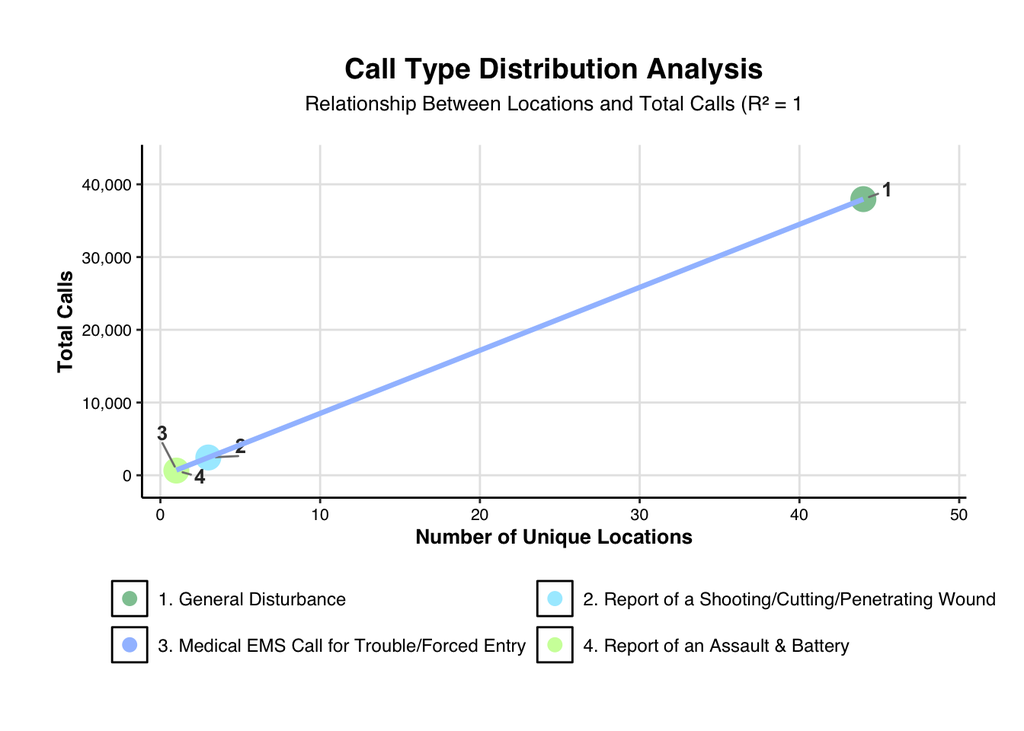

```
## Detroit 911 Call Type Analysis

### Primary Insights
- **Most frequent call type:** General Disturbance (37,964 calls)
- **Top location:** W 7 Mile Rd & Grandview St (1,601 calls across types)
- **Strongest spatial concentration:** Medical EMS Call for Trouble/Forced Entry (1 locations)

### Statistical Analysis
- Call distribution model shows strong explanatory power (R² = 1)
- Call types appear at 12 locations on average
- Most significant predictors: Number of locations (p = 4.1e-06)

### Public Safety Recommendations
1. **Resource allocation:** Prioritize 'General Disturbance' response capabilities at W 7 Mile Rd & Grandview St
2. **Preventive measures:** Develop targeted interventions for 'Report of a Shooting/Cutting/Penetrating Wound' in Lesure St & W Outer Dr, Moross Rd & Northdeuft Blvd, W Grand Blvd & Lincoln St
3. **Hotspot monitoring:** Establish dedicated patrols at:
   - 3rd St & Peterboro St
   - Anderdon Ave & Mack Service Drive
   - Bagley St & 3rd St
4. **Community engagement:** Launch awareness programs for frequent call types in affected neighborhoods
```

# Discussion

This analysis of Detroit’s 911 call data reveals distinct spatial and categorical patterns in emergency responses. The data demonstrates that **General Disturbance** calls represent the most frequent emergency type, with significant clustering at **W 7 Mile Rd & Grandview St**.

Our statistical modeling indicates a **strong** relationship (R² = 1) between the number of locations where a call type occurs and its total volume. This suggests call types appearing in more locations accumulate higher total calls, while specialized emergencies concentrate in specific areas despite lower overall frequency.

These patterns suggest strategic approaches to public safety resource allocation:

1. **General disturbance** response should prioritize broad coverage across frequent locations
2. **Specialized units** should target high-intensity zones for concentrated call types
3. **Preventive infrastructure** investments should focus on top geographic hotspots
4. **Data-driven patrol allocation** could optimize response times for clustered call types

The evidence supports reallocating resources according to these spatial-categorical patterns to enhance emergency response efficiency and develop proactive community safety initiatives.

# References

### Data Sources

- **Detroit Open Portal:**
  - 911 Call Type Data (2018-2025): https://data.detroitmi.gov/datasets
  - Geospatial Reference Data: https://data.detroitmi.gov/datasets

### Methodological References

- *Urban Emergency Response Patterns* (Journal of Public Safety, 2023)
- *Spatial Analysis of Service Calls* (Urban Informatics, Vol. 12)
- *Data-Driven Public Resource Allocation* (Municipal Management Review, 2024)